# HW2 - DATA 609

Thomas Hill

September 18, 2021

**Ex. 1** – Show that $x^2 + exp(x) + 2x^4 + 1$ is convex.

**This function f(x) is convex if the following is true:**

$$f(\alpha x + \beta y) \leq \alpha f(x) + \beta f(y), \alpha \geq 0, \beta \geq 0, \alpha + \beta = 1$$

**However, the consequent equation is time-consuming to simplify. One property of convex functions makes determining this easier:**

**If $f_1$ and $f_2$ are convex, then $\alpha f_1 + \beta f_2$ is also convex for any $\alpha, \beta \geq 0$.**

**Consider $f_1 = x^2, $f_2 = 2x^4 + 1$, and $f_3 = exp(x)$:**

$$f_1: (\alpha x + \beta y)^2 \leq \alpha x^2 + \beta y^2$$
**A similar quadratic funciton has larady been solved in the lesson, but to recap:**

$$0 \leq \alpha x^2 + \beta y^2 - (\alpha x + \beta y)^2$$

$$0 \leq \alpha x^2 - \alpha^2 x^2 + \beta y^2 - \beta ^2 y^2 - 2\alpha \beta xy$$
**Factor out $\alpha$ and $\beta$ terms:**
$$0 \leq \alpha x^2 ( 1 - \alpha ) + \beta y^2 (1 - \beta) - 2\alpha \beta xy = \alpha \beta x^2 + \alpha \beta y^2 - 2\alpha \beta xy$$

$$\alpha \beta (x^2 - 2xy - y^2) = \alpha \beta (x - y)^2 \geq 0$$

**This inequality is always true for real numbers. Next, consider whether $exp(x)$ is convex:**

$$f_2: exp(\alpha x + \beta y) \leq \alpha exp(x) + \beta exp(y)$$

$$0 \leq \alpha exp(x) + \beta exp(y) - exp(\alpha x + \beta y)$$

**Divide by $exp(x)$, which is permissible as this can never be equal to zero:**

$$0 \leq \alpha + \beta exp(y - x) - exp(\alpha x + \beta y - x) = \alpha + \beta exp(y - x) - exp(\beta y - x(1-\alpha))$$

$$0 \leq = \alpha + \beta exp(y - x) - exp(\beta (y - x)) = \alpha -exp(\frac{(y-x)^\beta}{\beta(y-x)}) = \alpha + \alpha exp(\frac{(y-x)}{\beta})$$

**After much simplifying, we’re left with two terms, both of which are non-negative for all real numbers. Therefore exp(x) is convex.**

**Finally, $f_3 = x^4 + 1$ is convex owing to the property of convex functions as follows:**

**If f(x) and g(x) are convex, then f(g(x))s convex under non-decreasing conditions. The f(x) and g(x) in this question are $f(x) = x^2$ and $g(x) = x^2 +1$.**

**Taken all together, the original function is convex.**

**Ex. 2** – Show that the mean of the exponential distribution

$$p(x) = \begin{cases}
\ \lambda e^{-\lambda x}, & 0 < \lambda \leq x \\
0, & x < 0
\end{cases}$$

is $\mu = \frac{1}{\lambda}$ and its variance is $\sigma ^2 = \frac{1}{\lambda^2}$.

**The mean $mu$ of a continuous probability distribution p(x) is defined as:**

$$\mu = E(x) = \int x p(x) dx$$

**For the exponential distribution, this can be integrated by parts, e.g., $\int u dv = uv - \int v du$**

$$\int ^\infty _0 x \lambda e^{-\lambda x} = -x e^{-\lambda x} - \int e^{-\lambda x} = -e^{-\lambda x}(\frac{1}{\lambda}+x)|^\infty _0$$

**Using the limit of exp(-x) = 0 as x approaches infinity:**

$$-\frac{e^{-\lambda x}}{\lambda}(1+x)|^\infty _0 = 0 + (\frac{1}{\lambda}+0) = \frac{1}{\lambda}$$

$$Var(x) = E[x^2] = (\int x^2 f(x) dx) - \mu^2$$

**where $\mu$ is the mean. Substituting in for the exponential distribution:**

$$\int ^\infty _0 x^2 \lambda e^{-\lambda x} dx$$

**Using integration by parts again:**

$$\lambda \int ^\infty _0 x^2 e^{-\lambda x} dx = -x^2 e^{-\lambda x} + 2\int x e^{-\lambda x} dx = -x^2 e^{-\lambda x} - \frac{2}{\lambda}e^{-\lambda x}(\frac{1}{\lambda}+x)|^\infty _0$$

$$-x^2 e^{-\lambda x}+ 2\frac{e^{-\lambda x}}{\lambda}(1+x)|^\infty _0 = 0 + 0 + 0 +\frac{2}{\lambda} *\frac{1} {\lambda} = \frac{2}{\lambda^2}$$

$$\frac{2}{\lambda^2} - [\frac{1}{\lambda}]^2 = \frac{1}{\lambda ^2}$$

**Ex. 3** – It is estimated that there is a typo in every 250 data entries in a database, assuming the number of typos can obey the Poisson distribution. For a given 1000 data entries, what is the probability that there are exactly 4 typos? What is the probability of no typo at all? Use *R* to draw 1000 samples with $\lambda = 4$ and show their histogram.

**The Poisson distribution is $p(x) \frac{\lambda^x e^{-x}}{x!}$, with x is the number of events we’re interested in observing, and $\lambda = np$, where n is the total number of occurences and p is the probability of an event. In this example, p = $\frac{1}{250}$, n = 1000 samples, and x = 4 typos. The exact solution is:**

```r
n = 1000
p = 1/250
x = 4

ex_3a <- ((n * p)^x * exp(-n*p))/factorial(x)

print(ex_3a)
```

```
## [1] 0.1953668
```

**Approximately 0.195 of exactly 4 typos.**

**The probability of no typos is:**

```r
n = 1000
p = 1/250
x = 0

ex_3b <- ((n * p)^x * exp(-n*p))/factorial(x)

print(ex_3b)
```

```
## [1] 0.01831564
```

**Approximately 0.018.**

**Using a Poisson random variable, below is a histogram of 1000 samples of $\lambda = 1000 * \frac{1}{250} = 4$**

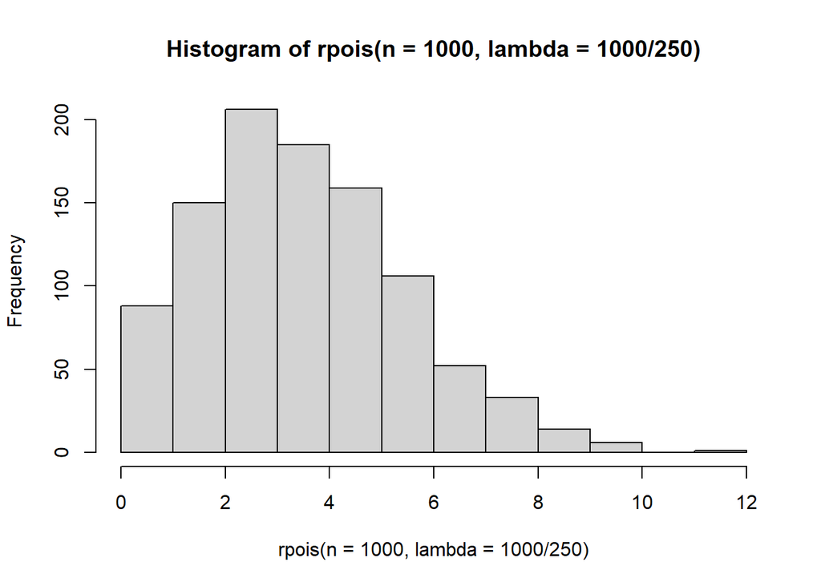

```r
set.seed(123)

hist(rpois(n = 1000, lambda = 1000/250))
```